# Tanzania People and Wildlife: Data Exploration and NDVI Time Series

Guy Lomax

2023-03-31

## Introduction

In this notebook, I generate smooth, high-resolution NDVI time series for Tanzania People and Wildlife rangeland monitoring plots from 2017-2022.

Sentinel-2 provides global satellite imagery at 5-day intervals and at 10-meter resolution, making it one of the most precise freely available satellite datasets currently available. Sentinel-2 imagery at 5-day intervals is available for East Africa from early 2017, providing about six years of continuous data.

The fine resolution of Sentinel-2 allows us to understand vegetation patterns and change on smaller scales than previously possible, to more easily distinguish between open areas and tree- or shrub-covered areas, and to connect remote sensing data to field data collected at the level of individual sample plots or transects.

## Load data and extract transect locations

TPW’s original rangeland monitoring data were in the form of a layer in ArcPro. I have converted the data into a Shapefile and a CSV to load into R.

The original data contains 7273 rows, each representing a sampling event of one of 227 TPW rangeland monitoring plots.

For now, I clean the data by removing sampling events that have fewer or more than 20 associated measurements along the transect, as well as those with greater than 100 total strikes reported for bare + basal ground cover (they should sum to no more than 100).

Extracting the coordinates of the transects is challenging because each sampling event has its own coordinates, which sometimes show more than one location for a single plot.

To ensure locations are accurate, I have removed plots with less than 12 months of data, and then removed those for which more than half of the recorded locations are more than 50m from the median location. For the remaining points (148 plots), I have assumed the median location reflects the true centre of the plot.

[interactive chart not shown]

I then exported these locations to be used in Google Earth Engine to extract Sentinel-2 vegetation index values for the plots.

## Combine with Sentinel-2 NDVI time series data from Google Earth Engine

The GPS coordinates of the transect locations were used to extract local NDVI (Normalised Difference Vegetation Index) and MSAVI2 (Modified Soil-Adjusted Vegetation Index) values for all Sentinel-2 images intersecting the location from 2017-2022 at 10m resolution. I extracted the mean values across a circle of 50m radius centred on the plot location, excluding pixels identified as tree, shrub or other non-grassy land cover.

I have randomly selected six of the monitoring transect locations to visualise the NDVI time series.

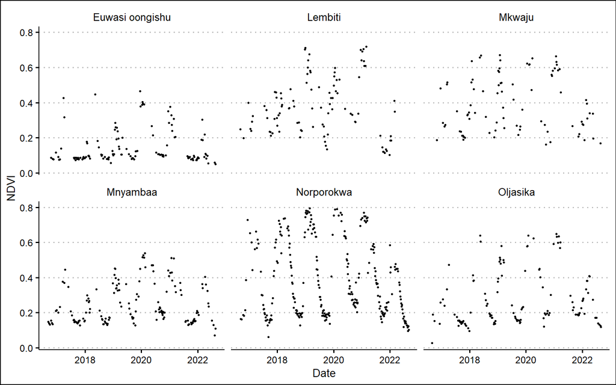

As can be seen, the raw time series contains noise and many missing values due to cloud cover and variable atmospheric conditions. We can fill these gaps using an intelligent smoothing approach to create a continuous time series that approximates the true time series values (based on Chen et al. 2004). The method relies on two facts: (a) Real NDVI tends to change smoothly, without abrupt spikes or drops. (b) Cloud cover and other disturbances tend to reduce NDVI values compared to their true values.

This means that we can make a best guess of the “true” value by fitting a curve to the upper envelope of the time series. To do this we use a Savitzky-Golay filter, which smooths out the jagged noise in the time series, and use it to boost unusually low values in the time series towards the upper envelope.

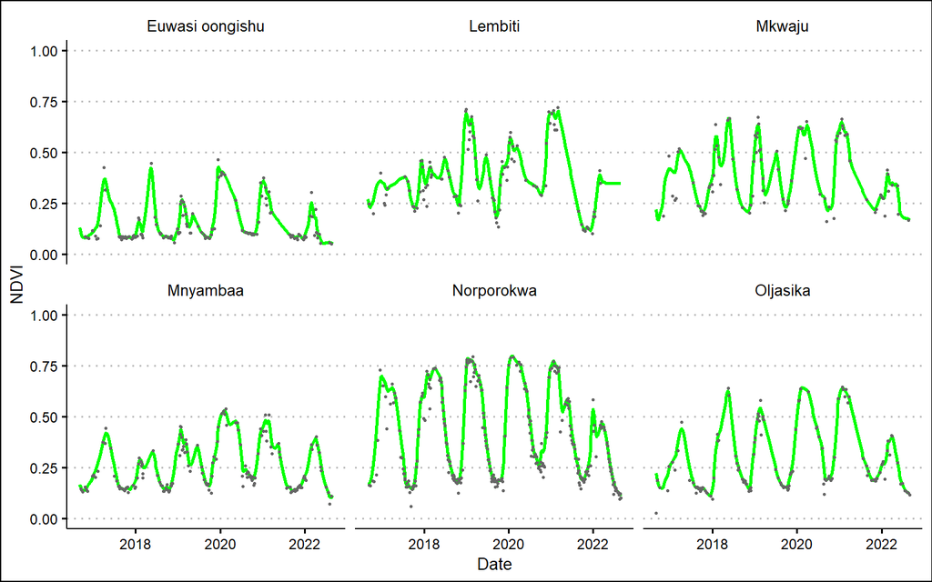

The grey shows the original data, while the green shows the smoothed version. It isn’t perfect - it still tends to give a spiky pattern when there is a lot of noise or not much data (e.g., in Lembiti) - but it is a big improvement on the original data. I am continuing to refine this.

The annual seasonal cycle is very clearly visible, and you can clearly see the differences between sites like Mnyambaa and those like Norporokwa. The smoother also preserves the overall shape of the increase at the start of each wet season and the subsequent decrease.

## Extracting vegetation metrics from satellite data

From these curves, we can start to extract some potentially useful metrics to track land health, degradation and resilience. A few we might be interested in are:

1. The peak greenness each year compared to baseline.
2. The overall area below the curve, a proxy for productivity.
3. The relationship between these values and seasonal rainfall.

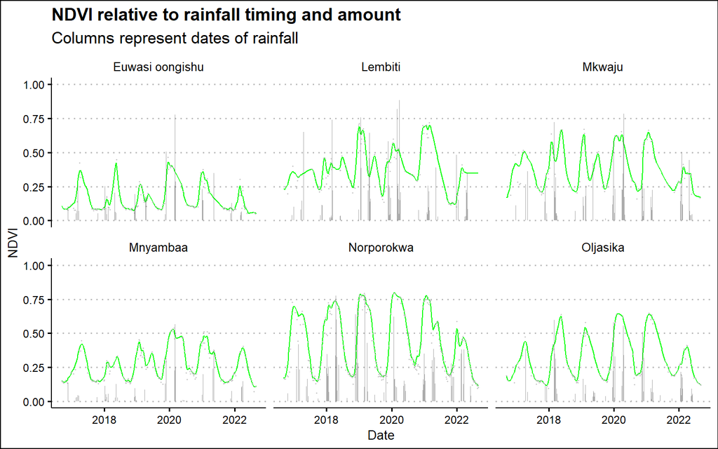

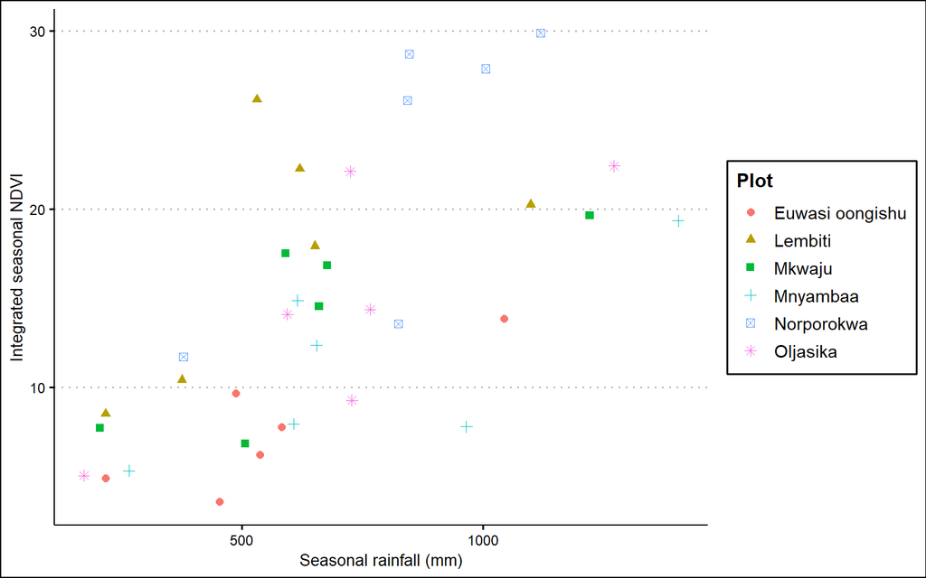

Another indicator of interest may be the recovery rate and decay rate of NDVI at the start or end of the season. More rapid recovery and greater persistence of green vegetation in the dry season may be associated with greater vegetation resilience and the presence of perennial grasses and herbs in addition to annual species.

We can quantify this for each site by fitting growth and decay curves to the NDVI profile for each year.

In the section below, the first figure shows an example of models fitted to the growth phase (start of the growing season) and the decay phase (end of the growing season). In some cases, the model hasn’t been able to fit the shape of the curve, because the shape is irregular.

Fitting these statistical models to the data allows us to extract the growth rate and decay rate of each season as a single number. We can then use these growth rates to explore how plots are changing over time, and examine whether this is driven by rainfall or other factors (like change in vegetation). The second figure shows the distribution of growth rates and decay rates for all the plots over the period 2017-2022.

```
#> Fitting time - growth:  19.30465
```

```
#> Fitting time - decay:  41.25333
```

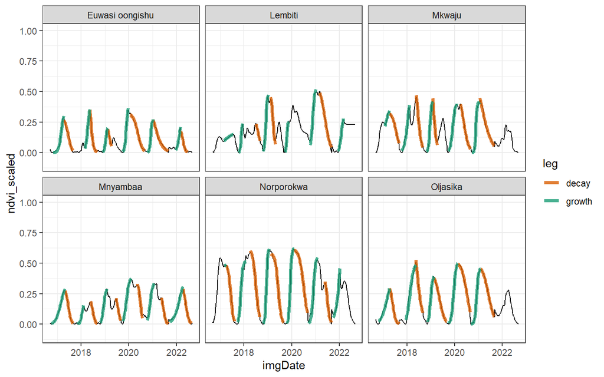

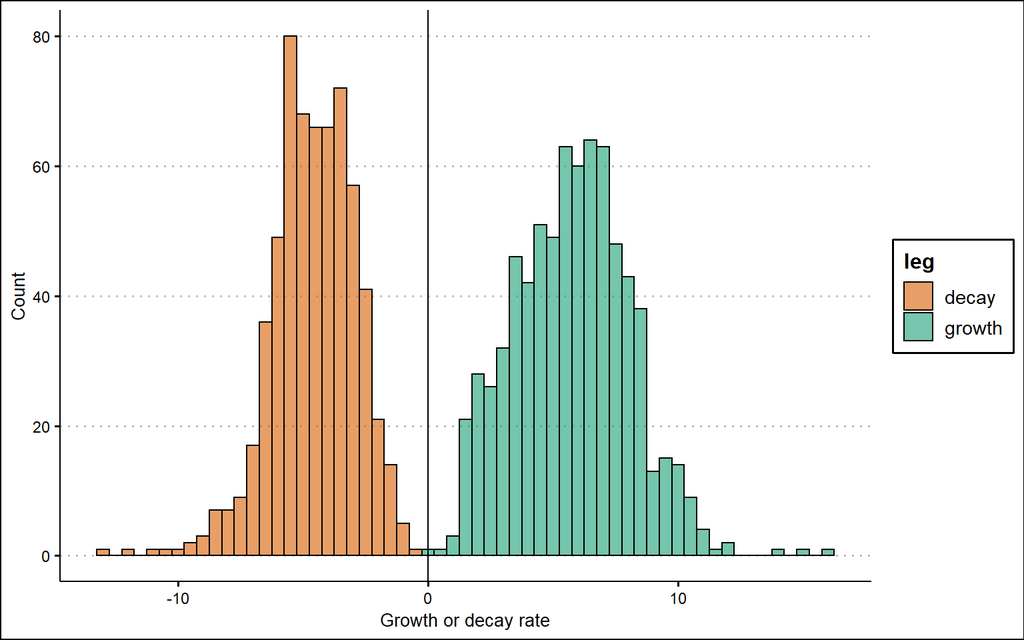

These models are not always a good fit to the data, but for the majority of time series they provide a way of quantifying the growth and decay rates of vegetation greenness over time.

From here, we could use these data in different ways:

1. We could look at changes over time in greenness, in recovery/decay rates or in other metrics like rain use efficiency, to explore which plots or areas are improving or deteriorating over time.
2. We could examine the drivers behind the differences in growth or decay rates, for example distinguishing the effects of rainfall, soil type or management.
3. We could compare these metrics between regions with similar areas outside the regions that TPW works in, for example to better understand impact.
4. We could compare some of these metrics to the field data TPW has collected, for example in order to test whether they allow us to predict ground cover or the presence of particular species.